# Counter Strike: Global Offensive; Player Analysis by Huang Yuebin

### Research Question 4: How does different sides affect a role's flashes, pistol rounds and opening kills?

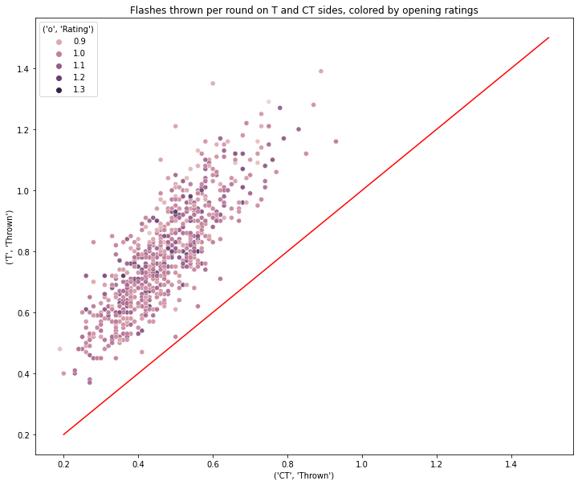

```python
plt.figure(figsize=(12,10))
sns.scatterplot(x=flashes.loc[:, ("CT", "Thrown")], y=flashes[("T", "Thrown")], hue=flashes[("o", "Rating")], alpha=0.9)
plt.plot([0.2, 1.5], [0.2, 1.5], color="Red")
plt.title("Flashes thrown per round on T and CT sides, colored by opening ratings")
plt.show()
```

As can be seen form this graph, Terrorists throw more flashes than Counter-Terrorists. However, no clear conclusion can be drawn from the differences between the entry fragging rating. This could be due to Terrorists having to be more aggresive and to push CT off their angles, which forces them to use more flashes to gain space and to get to the bombsite to plant the bomb.

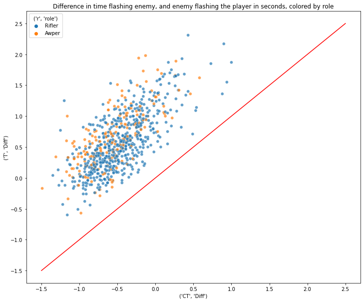

```python
plt.figure(figsize=(12,10))
sns.scatterplot(x=flashes.loc[:, ("CT", "Diff")], y=flashes[("T", "Diff")], hue=flashes[("r", "role")], alpha=0.7)
plt.plot([-1.5, 2.5], [-1.5, 2.5], color="Red")
plt.title("Difference in time flashing enemy, and enemy flashing the player in seconds, colored by role")
plt.show()
```

On the T side, players will tend to blind the enemy more often than getting blinded by the enemy as compared to on the CT side. This could be due to the aforementioned reason, being that CT tend to hold angles more, so they are more prone to being flashed, causing T side to have better flash statistics.

It can be noted that AWPers tend to have a higher Diff value on the T side and a lower value on the CT side. This may be because AWPers have a slow movement speed due to the weight of the gun, which forces them to use flashes more often on T side to peek riskier angles as compared to Riflers. AWPers on CT side also tend to get flashed for longer, as it may be because it is also harder to dodge flashes while scoped in on the AWP, as well as being flashed more often by the enemy when they know that an AWPer is posted at a certain angle since it is risky to fight an AWPer.

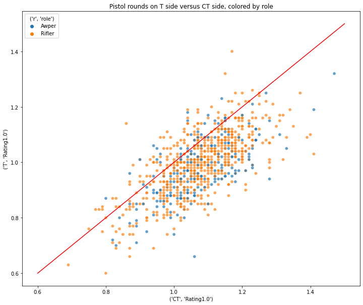

```python
plt.figure(figsize=(12,10))
sns.scatterplot(x=pistol.loc[:, ("CT", "Rating1.0")], y=pistol[("T", "Rating1.0")], hue=pistol[("r", "role")], alpha=0.7)
plt.plot([0.6, 1.5], [0.6, 1.5], color="Red")
plt.title("Pistol rounds on T side versus CT side, colored by role")
plt.show()
```

On the CT side, players tend to have a higher pistol rating than Terrorists. There is no clear correlation between these stats and the player's role. This could be due to the fact that CT has stronger pistol weapons that guarantee a one shot headshot kill, which helps boost their statistics on CT pistol rounds.

In conclusion, each side has their own benefits and detriments. On T side players are less likely to be flashed, whereas on CT side players have a slightly easier pistol round than T side players. The side also marginally affects the roles, where AWPers on T side flashes more often than AWPers on CT side, and also get flashed more often on CT side.

### Research Question 5: How does a player's role affect their performance?

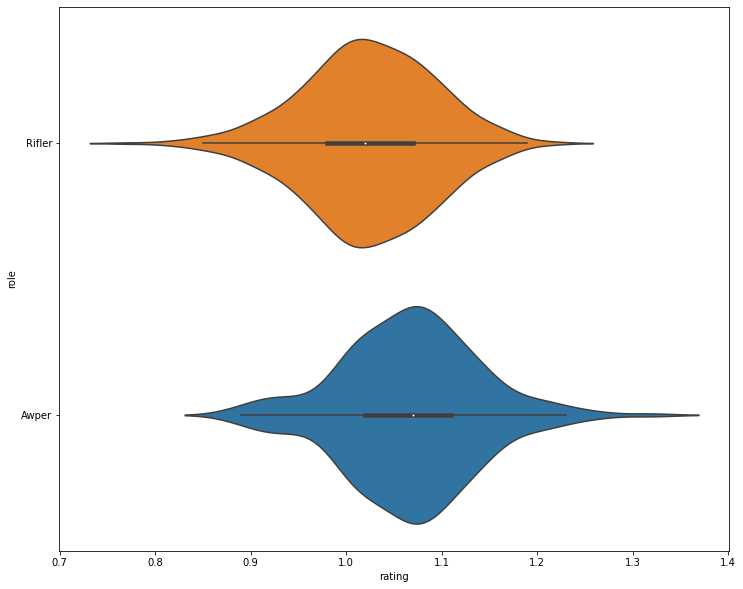

```python
plt.figure(figsize=(12,10))
sns.violinplot(y=players["role"], x=players["rating"], palette=["#ff7f0e", "#1f77b4"])
plt.show()
```

As can be seen from this violinplot, Awpers tend to have a higher rating than Riflers, where it has a higher median as well as a higher inter-quartile range. This could be due to the fact that Awpers have an easier time getting kills, due to Awp only requiring a bodyshot to kill, while rifle requires a few bodyshots or a headshot to kill. It could also be due to the role of Awpers generally being played by more skilled players so as to capitalise on this powerful weapon, which shifts the distribution of the Awper's rating to be higher.

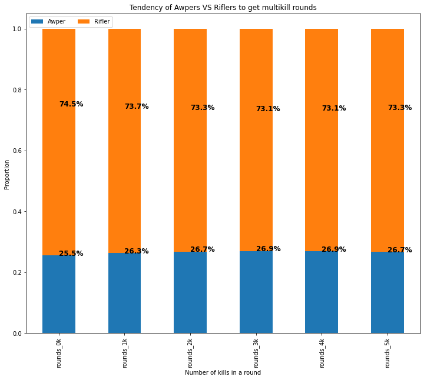

```python
pivot = players.groupby(["role"]).sum().loc[:, "rounds_0k":"rounds_5k"]
pivot = pivot / pivot.sum()
pivot.T.plot(kind='bar', stacked=True, figsize=(12,10))

plt.legend(loc="upper left", ncol=2)
plt.xlabel("Number of kills in a round")
plt.ylabel("Proportion")


for n, x in enumerate([*pivot.T.index.values]):
    for proportion in pivot.T.loc[x]:

        plt.text(x=n,
                 y=proportion,
                 s=f'{np.round(proportion * 100, 1)}%',
                 color="black",
                 fontsize=12,
                 fontweight="bold")
plt.title("Tendency of Awpers VS Riflers to get multikill rounds")
plt.show()
```

There is little correlation of roles to number of kills in a round. However, one may argue that Awpers tend to get slightly more multikills as the percentage increases from 25.5% in rounds with 0 kills to 26.9% in rounds with 4 kills for Awpers.

This shows that the role of the player does not significantly affect how likely it is for players to get multikills.

In conclusion, the role of the player does affect their HLTV rating, as AWPers tend to get higher ratings than Riflers, which may be caused by the nature of the weapon, or by teams placing skilled players on the role of the AWPer.

The role however does not affect their performance in terms of multikills in a round.

# Recommendations or Further Works

For further works, what could be done is to collect more data from Matches itself, instead of solely from the players. This is because CSGO is a team-based 5v5 game, and a team is not made of just individual players playing their own game. Synergy matters and that is not really shown in any stats. However due to the limitations of the web scraper I decided to focus more on the individual players in this report. Matches would show a team as a whole, their performance together, their highs and lows, which is what makes viewers attached to the esports side of CSGO.

# References

You may wish to read about how to use markdown in Jupyter notebook to make your report easier to read.

- https://www.ibm.com/docs/en/db2-event-store/2.0.0?topic=notebooks-markdown-jupyter-cheatsheet
- https://www.hltv.org/